# Cancer Genetics PCA

Shaina Race

Read in the data. The load() function reads in a dataset that has 20532 columns and may take some time. You may want to clear your environment (or open a new RStudio window) if you have other work open.

```r
load('geneCancerUCI.RData')
table(cancerlabels$Class)
```

```
##
## BRCA COAD KIRC LUAD PRAD
##  300   78  146  141  136
```

Original Source: *The cancer genome atlas pan-cancer analysis project*

- BRCA = Breast Invasive Carcinoma
- COAD = Colon Adenocarcinoma
- KIRC = Kidney Renal clear cell Carcinoma
- LUAD = Lung Adenocarcinoma
- PRAD = Prostate Adenocarcinoma

We are going to want to plot the data points according to their different classification labels. We should pick out a nice color palette for categorical attributes.

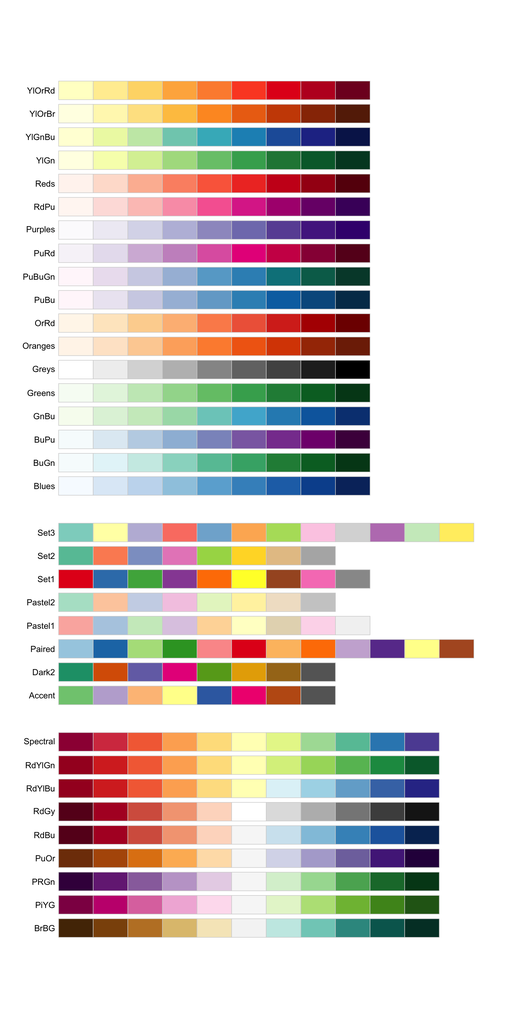

```r
library(RColorBrewer)
display.brewer.all()
```

```r
palette(brewer.pal(n = 8, name = "Dark2"))
```

The first step is typically to explore the data. Obviously we can’t look at ALL the scatter plots of input variables. For the fun of it, let’s look at a few of these scatter plots which we’ll pick at random. First pick two column numbers at random, then draw the plot, coloring by the label.

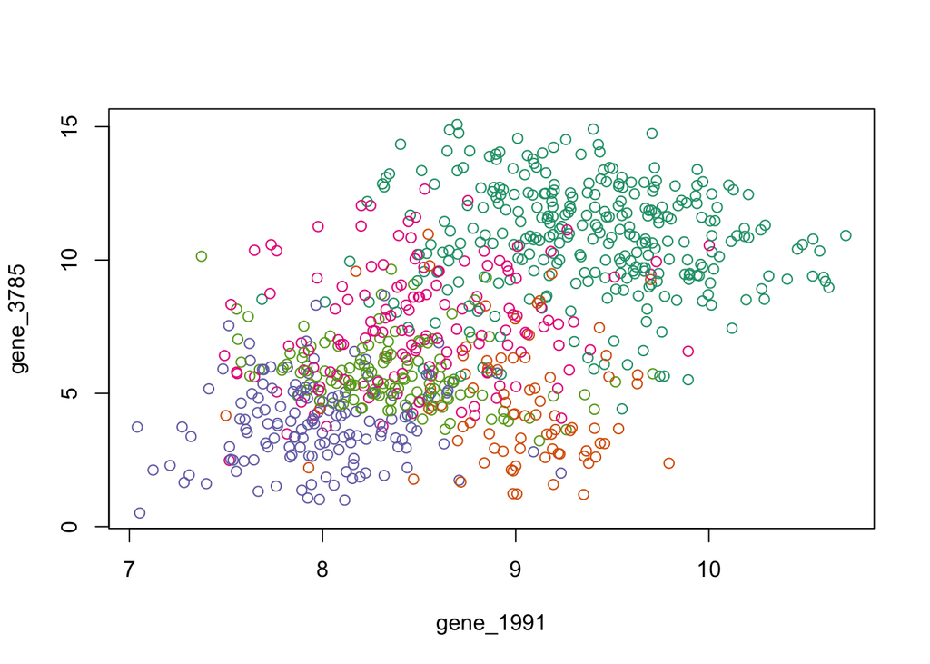

```r
randomColumns = sample(2:20532,2)
plot(cancer[,randomColumns],col = cancerlabels$Class)
```

The *prcomp* function is the one I most often recommend for reasonably sized principal component calculations in R. This function returns a list with class “prcomp” containing the following components (from help prcomp):

1. *sdev*: the standard deviations of the principal components (i.e., the square roots of the eigenvalues of the covariance/correlation matrix, though the calculation is actually done with the singular values of the data matrix).
2. *rotation*: the matrix of *variable loadings* (i.e., a matrix whose columns contain the eigenvectors). The function princomp returns this in the element loadings.
3. *x*: if retx is true *the value of the rotated data* (the centred (and scaled if requested) data multiplied by the rotation matrix) is returned. Hence, cov(x) is the diagonal matrix diag(sdev^2). For the formula method, napredict() is applied to handle the treatment of values omitted by the na.action.
4. *center, scale*: the centering and scaling used, or FALSE.

Now let’s compute the *first two* principal components and examine the data projected onto these axes. We can then look in 3 dimensions.

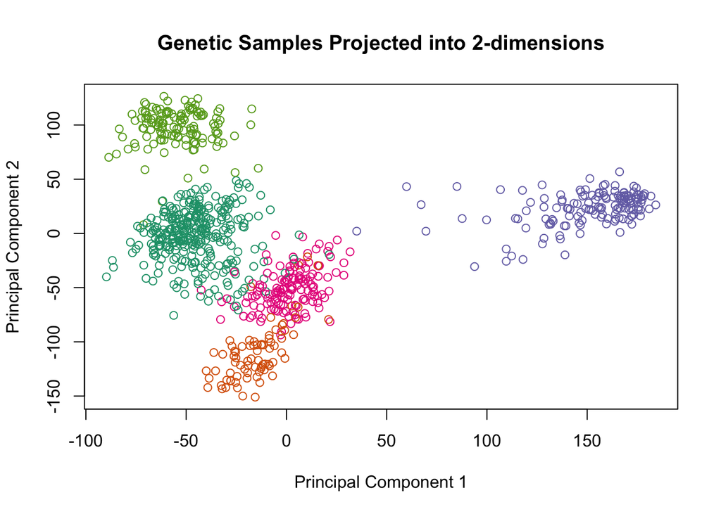

```r
pcaOut = prcomp(cancer[,2:20532],3, scale = F)
plot(pcaOut$x[,1],pcaOut$x[,2],col = cancerlabels$Class, xlab = "Principal Component 1", ylab = "Principal Component 2", main = 'Genetic Samples Projected into 2-dimensions')
```

3-dimensional plot. Problem is to get the plot points colored by group, we need to write a function that creates a vector of colors

```r
colors = factor(palette())
colors = colors[cancerlabels$Class]
```

Make sure the rgl package is installed for the 3d plot.

```r
library(rgl)
plot3d(x = pcaOut$x[,1], y = pcaOut$x[,2],z= pcaOut$x[,3],col = colors, xlab = "Principal Component 1", ylab = "Principal Component 2", zlab = "Principal Component 3")
```

Proportion of Variance explained by 2 components:

```r
sum(pcaOut$sdev[1:2]^2)/sum(pcaOut$sdev^2)
```

[output not shown]

Proportion of Variance explained by 3 components:

```r
sum(pcaOut$sdev[1:3]^2)/sum(pcaOut$sdev^2)
```

[output not shown]